# Through the eyes of the teacher - Multimodal exploration of expertise differences in the perception of classroom disruptions in a laboratory study

### Internal consistency (Omega) for disruption and confidence appraisal

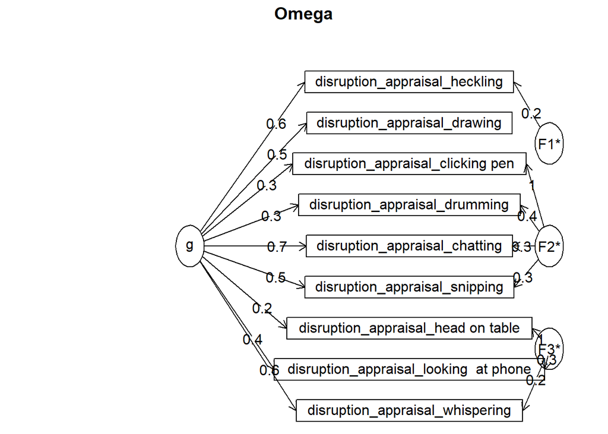

Omega Call: omegah(m = m, nfactors = nfactors, fm = fm, key = key, flip = flip, digits = digits, title = title, sl = sl, labels = labels, plot = plot, n.obs = n.obs, rotate = rotate, Phi = Phi, option = option, covar = covar) Alpha: 0.76 G.6: 0.81 Omega Hierarchical: 0.62 Omega H asymptotic: 0.73 Omega Total 0.84

Schmid Leiman Factor loadings greater than 0.2 g F1* F2* F3* h2 h2 u2 disruption_appraisal_whispering 0.60 0.22 0.45 0.45 0.55 disruption_appraisal_heckling 0.63 0.24 0.47 0.47 0.53 disruption_appraisal_drawing 0.47 0.27 0.27 0.73 disruption_appraisal_snipping 0.50 0.26 0.35 0.35 0.65 disruption_appraisal_looking at phone 0.38 0.32 0.26 0.26 0.74 disruption_appraisal_head on table 0.22 0.98 1.00 1.00 0.00 disruption_appraisal_clicking pen 0.34 0.95 1.02 1.02 -0.02 disruption_appraisal_drumming 0.34 0.37 0.28 0.28 0.72 disruption_appraisal_chatting 0.67 0.28 0.57 0.57 0.43 p2 com disruption_appraisal_whispering 0.80 1.52 disruption_appraisal_heckling 0.84 1.39 disruption_appraisal_drawing 0.82 1.45 disruption_appraisal_snipping 0.71 1.85 disruption_appraisal_looking at phone 0.57 2.12 disruption_appraisal_head on table 0.05 1.10 disruption_appraisal_clicking pen 0.11 1.25 disruption_appraisal_drumming 0.42 2.35 disruption_appraisal_chatting 0.80 1.52

With Sums of squares of: g F1* F2* F3* h2 2.10 0.19 1.22 1.16 3.13

general/max 0.67 max/min = 16.24 mean percent general = 0.57 with sd = 0.31 and cv of 0.54 Explained Common Variance of the general factor = 0.45

The degrees of freedom are 12 and the fit is 0.35 The number of observations was 53 with Chi Square = 16.18 with prob < 0.18 The root mean square of the residuals is 0.05 The df corrected root mean square of the residuals is 0.09 RMSEA index = 0.079 and the 10 % confidence intervals are 0 0.174 BIC = -31.47

Compare this with the adequacy of just a general factor and no group factors The degrees of freedom for just the general factor are 27 and the fit is 1.18 The number of observations was 53 with Chi Square = 56 with prob < 0.00086 The root mean square of the residuals is 0.13 The df corrected root mean square of the residuals is 0.16

RMSEA index = 0.141 and the 10 % confidence intervals are 0.09 0.197 BIC = -51.2

Measures of factor score adequacy  
g F1* F2* F3* Correlation of scores with factors 0.84 0.30 1.01 1.00 Multiple R square of scores with factors 0.70 0.09 1.02 0.99 Minimum correlation of factor score estimates 0.41 -0.82 1.03 0.99

Total, General and Subset omega for each subset g F1* F2* F3* Omega total for total scores and subscales 0.84 0.54 0.79 0.72 Omega general for total scores and subscales 0.62 0.47 0.39 0.28 Omega group for total scores and subscales 0.21 0.06 0.39 0.44

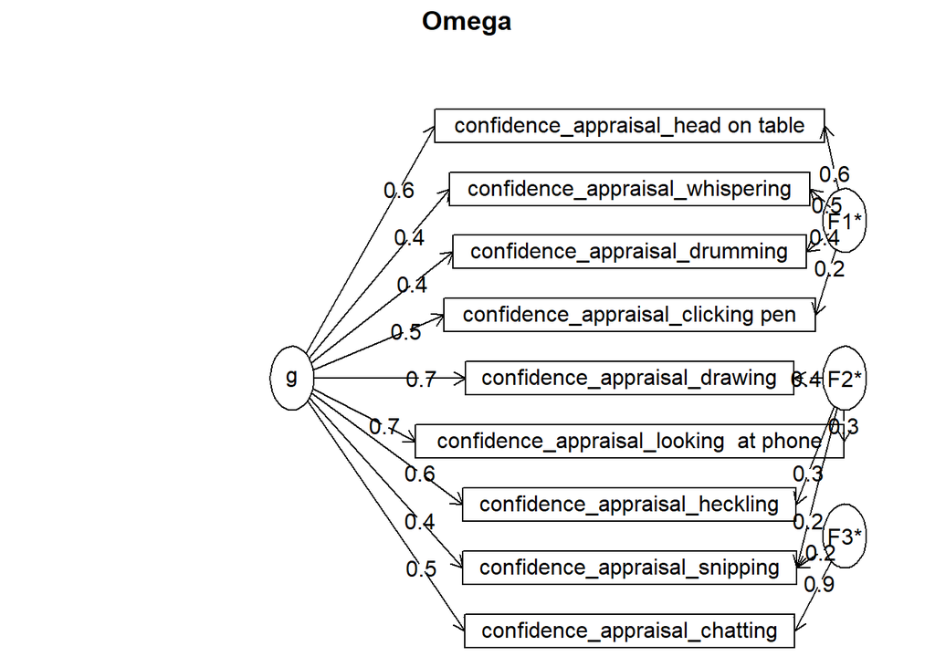

Omega Call: omegah(m = m, nfactors = nfactors, fm = fm, key = key, flip = flip, digits = digits, title = title, sl = sl, labels = labels, plot = plot, n.obs = n.obs, rotate = rotate, Phi = Phi, option = option, covar = covar) Alpha: 0.82 G.6: 0.84 Omega Hierarchical: 0.66 Omega H asymptotic: 0.76 Omega Total 0.87

Schmid Leiman Factor loadings greater than 0.2 g F1* F2* F3* h2 h2 u2 confidence_appraisal_whispering 0.39 0.48 0.40 0.40 0.60 confidence_appraisal_heckling 0.59 0.28 0.45 0.45 0.55 confidence_appraisal_drawing 0.70 0.36 0.62 0.62 0.38 confidence_appraisal_snipping 0.41 0.23 0.23 0.31 0.31 0.69 confidence_appraisal_looking at phone 0.66 0.32 0.57 0.57 0.43 confidence_appraisal_head on table 0.56 0.56 0.63 0.63 0.37 confidence_appraisal_clicking pen 0.48 0.20 0.31 0.31 0.69 confidence_appraisal_drumming 0.42 0.42 0.37 0.37 0.63 confidence_appraisal_chatting 0.50 0.87 1.00 1.00 0.00 p2 com confidence_appraisal_whispering 0.38 2.11 confidence_appraisal_heckling 0.76 1.62 confidence_appraisal_drawing 0.79 1.50 confidence_appraisal_snipping 0.55 2.69 confidence_appraisal_looking at phone 0.75 1.67 confidence_appraisal_head on table 0.50 2.03 confidence_appraisal_clicking pen 0.74 1.74 confidence_appraisal_drumming 0.49 2.10 confidence_appraisal_chatting 0.25 1.60

With Sums of squares of: g F1* F2* F3* h2 2.55 0.82 0.39 0.90 2.80

general/max 0.91 max/min = 7.18 mean percent general = 0.58 with sd = 0.19 and cv of 0.33 Explained Common Variance of the general factor = 0.55

The degrees of freedom are 12 and the fit is 0.33 The number of observations was 53 with Chi Square = 15.22 with prob < 0.23 The root mean square of the residuals is 0.05 The df corrected root mean square of the residuals is 0.09 RMSEA index = 0.069 and the 10 % confidence intervals are 0 0.167 BIC = -32.43

Compare this with the adequacy of just a general factor and no group factors The degrees of freedom for just the general factor are 27 and the fit is 0.87 The number of observations was 53 with Chi Square = 41.5 with prob < 0.037 The root mean square of the residuals is 0.12 The df corrected root mean square of the residuals is 0.14

RMSEA index = 0.099 and the 10 % confidence intervals are 0.026 0.16 BIC = -65.7

Measures of factor score adequacy  
g F1* F2* F3* Correlation of scores with factors 0.84 0.72 0.48 0.96 Multiple R square of scores with factors 0.70 0.52 0.23 0.92 Minimum correlation of factor score estimates 0.41 0.04 -0.55 0.83

Total, General and Subset omega for each subset g F1* F2* F3* Omega total for total scores and subscales 0.87 0.71 0.77 1.00 Omega general for total scores and subscales 0.66 0.40 0.61 0.25 Omega group for total scores and subscales 0.15 0.32 0.16 0.75